# Examining the factors that influence Depression

## Desc of medication help

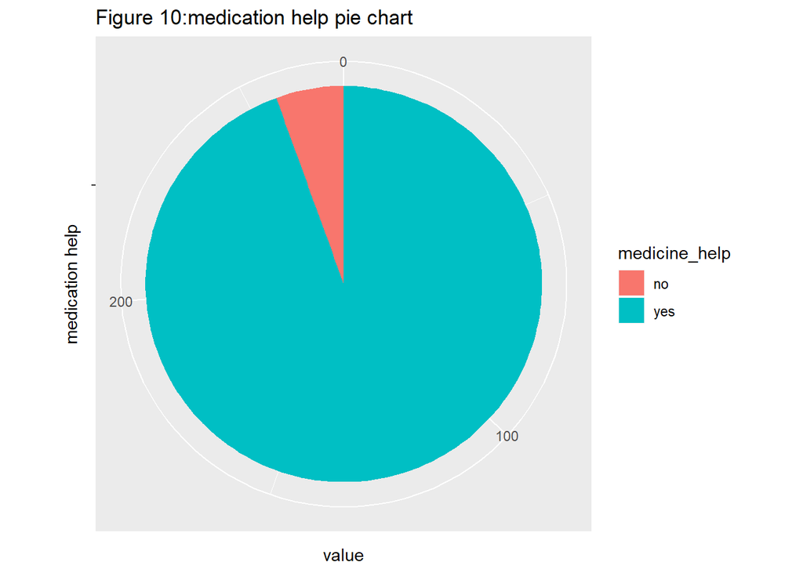

```r
bar <- ggplot(medication_help, aes(x=" ",y=value, fill=medicine_help))
bar<- bar +geom_bar(width = 0.5, stat = "identity") + labs(x="medication help", title="Figure 9: medication help bar graph")

#pie chart formation
pie<-bar+coord_polar(theta = 'y')+ labs( title="Figure 10:medication help pie chart")

pie
```

```r
# creating new data and omiting missing value

sleep_copy <- data.frame(sleep$anxiety, sleep$totsas, sleep$problem, sleep$medhelp)
names(sleep_copy) <- c("anxiety", "totsas","problem", "medhelp" )
#adding the transformed depress variable into the new dataset that is tidy and will be used further
sleep_copy$newDepress<-newDepress
#removing the "na" values from the dataset
na.omit(sleep_copy)
```

```
##     anxiety totsas problem medhelp newDepress
## 1         2     10       2       2   1.000000
## 2         6     20       2       2   1.414214
## 3         9     31       2       1   3.162278
## 4         8     34       2       2   1.732051
## 5         4     25       2       2   0.000000
## 6        12     33       2       2   2.449490
## 8        13     37       2       2   3.316625
## 10        1     16       2       2   0.000000
## 11        5     35       1       2   2.000000
## 12        7     14       2       2   0.000000
## 13        3     28       2       2   1.732051
## 14       12     40       1       2   3.464102
## 15        4     33       2       2   0.000000
## 16        6     25       2       2   1.414214
```

[output cut: 233 more lines]

```r
#View(sleep_copy)
```

## Spearmen test for corelation

```r
#spearman correlation
cor.test(sleep_copy$newDepress, sleep_copy$anxiety, method = "spearman")
```

```
##
##  Spearman's rank correlation rho
##
## data:  sleep_copy$newDepress and sleep_copy$anxiety
## S = 1359800, p-value < 2.2e-16
## alternative hypothesis: true rho is not equal to 0
## sample estimates:
##       rho
## 0.5761479
```

```r
#kendall correlation to calculate accute p-value
cor.test(sleep_copy$newDepress, sleep_copy$anxiety, method = "kendall")
```

```
##
##  Kendall's rank correlation tau
##
## data:  sleep_copy$newDepress and sleep_copy$anxiety
## z = 9.7512, p-value < 2.2e-16
## alternative hypothesis: true tau is not equal to 0
## sample estimates:
##       tau
## 0.4373734
```

[figure not shown]

```r
#creating scatter plot
scatter<-ggplot(sleep_copy, aes(sleep_copy$newDepress, sleep_copy$anxiety))
scatter + geom_point()+ geom_smooth(method = 'lm', colour='pink', se=F)+ labs(x="Level of Depression", y="hour sleep on week days ")
```

## Pearson test for correlation

```r
cor.test(sleep_copy$newDepress, sleep_copy$totsas, method = "pearson")
```

```
##
##  Pearson's product-moment correlation
##
## data:  sleep_copy$newDepress and sleep_copy$totsas
## t = 8.6856, df = 247, p-value = 5.246e-16
## alternative hypothesis: true correlation is not equal to 0
## 95 percent confidence interval:
##  0.3823747 0.5735275
## sample estimates:
##       cor
## 0.4836983
```

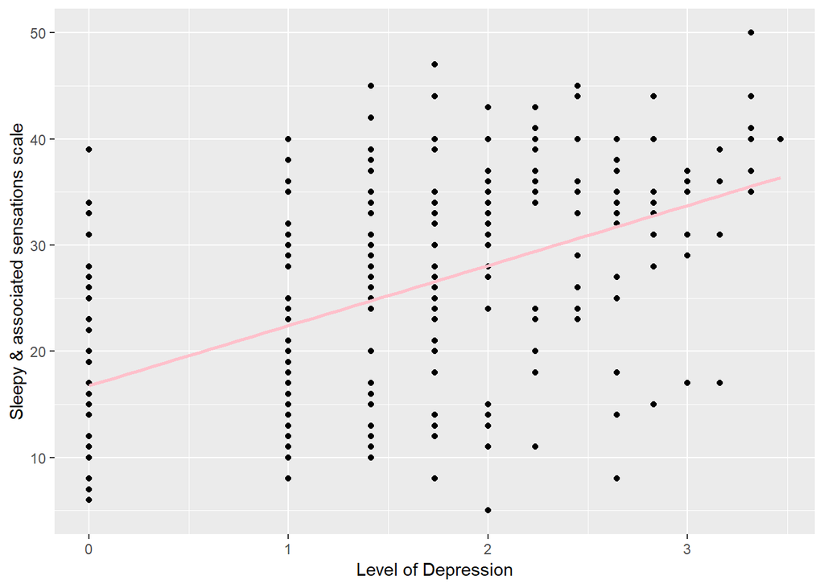

```r
#pearson correlation
#creating scatter plot
scatter<-ggplot(sleep_copy, aes(sleep_copy$newDepress, sleep_copy$totsas))
scatter + geom_point()+ geom_smooth(method = 'lm', colour='pink', se=F)+ labs(x="Level of Depression", y="Sleepy & associated sensations scale")
```

## t-test for depression and problem with sleep

```r
diff1<- psych::describeBy(sleep_copy$newDepress, group = sleep_copy$problem)
diff1
```

```
##
##  Descriptive statistics by group
## group: 1
##    vars   n mean   sd median trimmed  mad min  max range  skew kurtosis
## X1    1 117 1.93 0.82      2    1.96 0.87   0 3.46  3.46 -0.38    -0.05
##      se
## X1 0.08
## --------------------------------------------------------
## group: 2
##    vars   n mean  sd median trimmed  mad min  max range skew kurtosis   se
## X1    1 150 1.42 0.9   1.41     1.4 0.61   0 3.32  3.32 0.05    -0.62 0.07
```

```r
sleep_copy$problem<-as.factor(sleep_copy$problem)
#levene test
car::leveneTest(newDepress ~ problem, data=sleep_copy)
```

```
## Levene's Test for Homogeneity of Variance (center = median)
##        Df F value Pr(>F)
## group   1  0.9036 0.3427
##       265
```

```r
#t-test
stats::t.test(newDepress~problem,var.equal=FALSE,data=sleep_copy)
```

```
##
##  Welch Two Sample t-test
##
## data:  newDepress by problem
## t = 4.8648, df = 259.22, p-value = 1.991e-06
## alternative hypothesis: true difference in means is not equal to 0
## 95 percent confidence interval:
##  0.3061902 0.7226345
## sample estimates:
## mean in group 1 mean in group 2
##        1.933349        1.418937
```

```r
#cohen.d is used to find the effect size
#View(sleep_copy)
effsize::cohen.d(sleep_copy$newDepress, sleep_copy$problem, alpha = 0.05, std=TRUE, na.rm=TRUE)
```

```
##
## Cohen's d
##
## d estimate: -0.600071 (medium)
## 95 percent confidence interval:
##        inf        sup
## -0.8482532 -0.3518888
```

## t-test for depression and Medication Help

```r
diff1<- psych::describeBy(sleep_copy$newDepress, group = sleep_copy$medhelp)
diff1
```

```
##
##  Descriptive statistics by group
## group: 1
##    vars  n mean   sd median trimmed mad min  max range  skew kurtosis  se
## X1    1 15 1.94 0.78      2    1.99 0.4   0 3.16  3.16 -0.67     0.27 0.2
## --------------------------------------------------------
## group: 2
##    vars   n mean   sd median trimmed  mad min  max range  skew kurtosis
## X1    1 254 1.62 0.91   1.73    1.63 1.06   0 3.46  3.46 -0.12    -0.56
##      se
## X1 0.06
```

```r
sleep_copy$medhelp<-as.factor(sleep_copy$medhelp)
#levene test
car::leveneTest(newDepress ~ medhelp, data=sleep_copy)
```

```
## Levene's Test for Homogeneity of Variance (center = median)
##        Df F value Pr(>F)
## group   1  1.2138 0.2716
##       267
```

```r
#t-test
stats::t.test(newDepress~medhelp,var.equal=FALSE,data=sleep_copy)
```

```
##
##  Welch Two Sample t-test
##
## data:  newDepress by medhelp
## t = 1.5071, df = 16.29, p-value = 0.1509
## alternative hypothesis: true difference in means is not equal to 0
## 95 percent confidence interval:
##  -0.1282522  0.7622357
## sample estimates:
## mean in group 1 mean in group 2
##        1.938878        1.621887
```

```r
#cohen.d is used to find the effect size
#View(sleep_copy)
effsize::cohen.d(sleep_copy$newDepress, sleep_copy$medhelp, alpha = 0.05, std=TRUE, na.rm=TRUE)
```

```
##
## Cohen's d
##
## d estimate: -0.4006731 (small)
## 95 percent confidence interval:
##        inf        sup
## -0.9249378  0.1235916
```

A Levene’s test for homogeneity of variance was conducted and indicated equality of variance for the level of depression for medication help(yes) or not medication help(no) respondents (F=1.213, Pr=0.271). An independent-samples t-test was conducted to compare depression level for yes and no respondents. No significant difference in the scores for was found (M=1.94, SD= 0.78 for yes respondents, M= 1.62, SD= 0.91 for no respondents), (t=1.5071, p = 0.150). The cohen.d test result (-0.40(small)).

#### RESULTS

```r
model1<-lm(sleep_copy$newDepress ~ sleep_copy$totsas + sleep_copy$problem)
anova(model1)
```

```
## Analysis of Variance Table
##
## Response: sleep_copy$newDepress
##                     Df  Sum Sq Mean Sq F value    Pr(>F)
## sleep_copy$totsas    1  46.463  46.463 73.5998 1.127e-15 ***
## sleep_copy$problem   1   0.003   0.003  0.0049    0.9443
## Residuals          244 154.034   0.631
## ---
## Signif. codes:  0 '***' 0.001 '**' 0.01 '*' 0.05 '.' 0.1 ' ' 1
```

```r
summary(model1)
```

```
##
## Call:
## lm(formula = sleep_copy$newDepress ~ sleep_copy$totsas + sleep_copy$problem)
##
## Residuals:
##      Min       1Q   Median       3Q      Max
## -2.17020 -0.47913  0.03473  0.57619  1.90213
##
## Coefficients:
##                      Estimate Std. Error t value Pr(>|t|)
## (Intercept)          0.571764   0.197028   2.902  0.00405 **
## sleep_copy$totsas    0.040985   0.005652   7.252 5.42e-12 ***
## sleep_copy$problem2 -0.008372   0.119622  -0.070  0.94426
## ---
## Signif. codes:  0 '***' 0.001 '**' 0.01 '*' 0.05 '.' 0.1 ' ' 1
##
## Residual standard error: 0.7945 on 244 degrees of freedom
##   (24 observations deleted due to missingness)
## Multiple R-squared:  0.2317, Adjusted R-squared:  0.2255
## F-statistic:  36.8 on 2 and 244 DF,  p-value: 1.075e-14
```

```r
stargazer(model1, type="text") #Tidy output of all the required stats
```

```
##
## ===============================================
##                         Dependent variable:
##                     ---------------------------
##                             newDepress
## -----------------------------------------------
## totsas                       0.041***
##                               (0.006)
##
## problem2                      -0.008
##                               (0.120)
##
## Constant                     0.572***
##                               (0.197)
##
## -----------------------------------------------
## Observations                    247
## R2                             0.232
## Adjusted R2                    0.225
## Residual Std. Error      0.795 (df = 244)
## F Statistic           36.802*** (df = 2; 244)
## ===============================================
## Note:               *p<0.1; **p<0.05; ***p<0.01
```

```r
#check assumptions
#cook distance
cooks.distance(model1)
```

```
##            1            2            3            4            5
## 5.252447e-06 3.843271e-06 1.181358e-02 4.367284e-04 1.102423e-02
##            6            8           10           11           12
## 2.258035e-03 1.702466e-02 6.899824e-03 1.979090e-07 6.870041e-03
##           13           14           15           16           17
## 2.342510e-06 1.026084e-02 2.911282e-02 1.320693e-04 3.308098e-02
##           18           19           20           21           22
## 2.844688e-03 3.876585e-03 1.208987e-02 2.672438e-04 9.058498e-03
##           23           24           25           26           27
## 1.291972e-02 5.608055e-05 3.204644e-03 7.585418e-03 1.431034e-04
##           28           29           30           31           32
## 8.221521e-04 2.229644e-04 1.798192e-03 1.511567e-03 7.304634e-03
##           33           34           36           37           38
## 2.066192e-04 4.682557e-03 2.757418e-04 7.086580e-04 1.079065e-03
##           39           40           41           42           43
## 1.312130e-02 3.780159e-03 6.621599e-03 2.971613e-04 3.804404e-04
##           44           45           46           47           48
## 6.899824e-03 3.804404e-04 3.737069e-04 1.366115e-06 2.888564e-03
##           49           53           54           55           56
## 5.608055e-05 2.420539e-04 9.067692e-05 1.438426e-04 9.103457e-03
##           57           58           59           61           62
## 1.372082e-02 2.716105e-04 1.006916e-02 7.097046e-05 5.357719e-04
##           63           64           65           66           67
## 1.256663e-02 8.577910e-04 4.746391e-04 2.757418e-04 1.965200e-04
##           68           69           70           71           72
## 2.888564e-03 4.902541e-05 6.972750e-03 5.797290e-04 1.511567e-03
##           73           74           75           76           77
## 1.571148e-04 6.899824e-03 7.086580e-04 1.588713e-02 3.330415e-03
##           79           80           81           82           83
## 4.682557e-03 1.879872e-03 9.176129e-03 2.757418e-04 1.984892e-03
##           85           86           87           88           89
## 1.766160e-04 3.804404e-04 9.998328e-05 6.914152e-03 1.225399e-02
##           90           91           92           93           94
## 6.938118e-03 1.079065e-03 3.804404e-04 1.431034e-04 1.426952e-03
##           95           96           97           98           99
## 7.376488e-05 1.486811e-04 2.785657e-03 3.342653e-03 2.971613e-04
##          100          101          103          104          105
## 9.998328e-05 8.867470e-03 1.079065e-03 4.656230e-03 1.766160e-04
##          106          107          108          109          110
## 6.950924e-03 1.726083e-03 6.732637e-04 9.176129e-03 3.804404e-04
```

[output cut: 45 more lines]

```
## 4.967526e-04 2.045524e-03 1.684836e-02 5.749914e-03 1.703875e-03
##          238          239          240          241          242
## 6.144832e-04 1.908647e-03 4.967526e-04 2.946125e-04 4.996955e-03
##          243          244          245          246          247
## 2.490305e-03 2.237397e-03 5.373713e-03 4.201905e-04 2.284208e-03
##          248          249          250          251          252
## 3.905504e-04 2.683024e-04 1.500524e-03 4.839685e-05 1.500524e-03
##          253          254          255          256          257
## 3.804517e-04 2.530357e-03 2.816584e-03 1.481935e-03 3.465296e-03
##          258          259          261          262          263
## 5.950416e-06 1.497929e-03 7.461131e-04 3.712065e-04 1.198145e-04
##          264          265          266          267          268
## 3.804517e-04 9.940867e-04 3.755906e-03 3.420434e-03 3.973952e-03
##          270          271
## 1.481935e-03 6.562262e-03
```

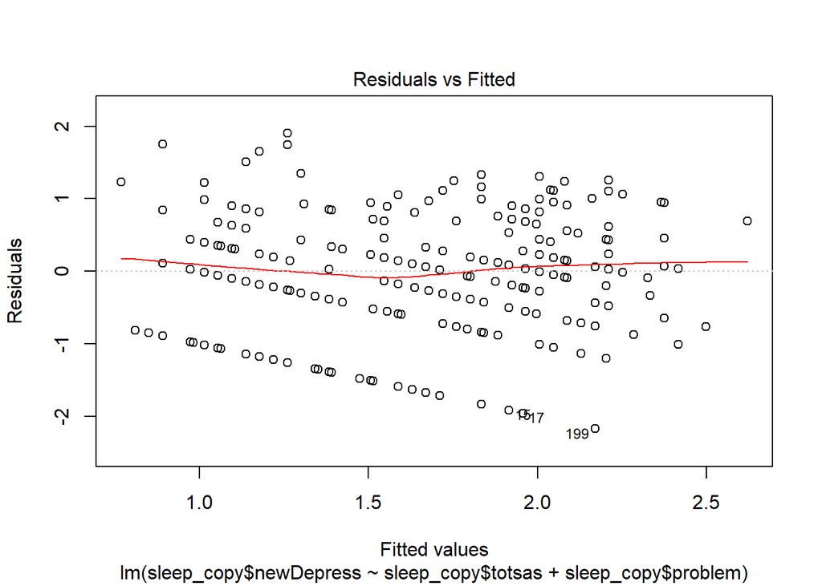

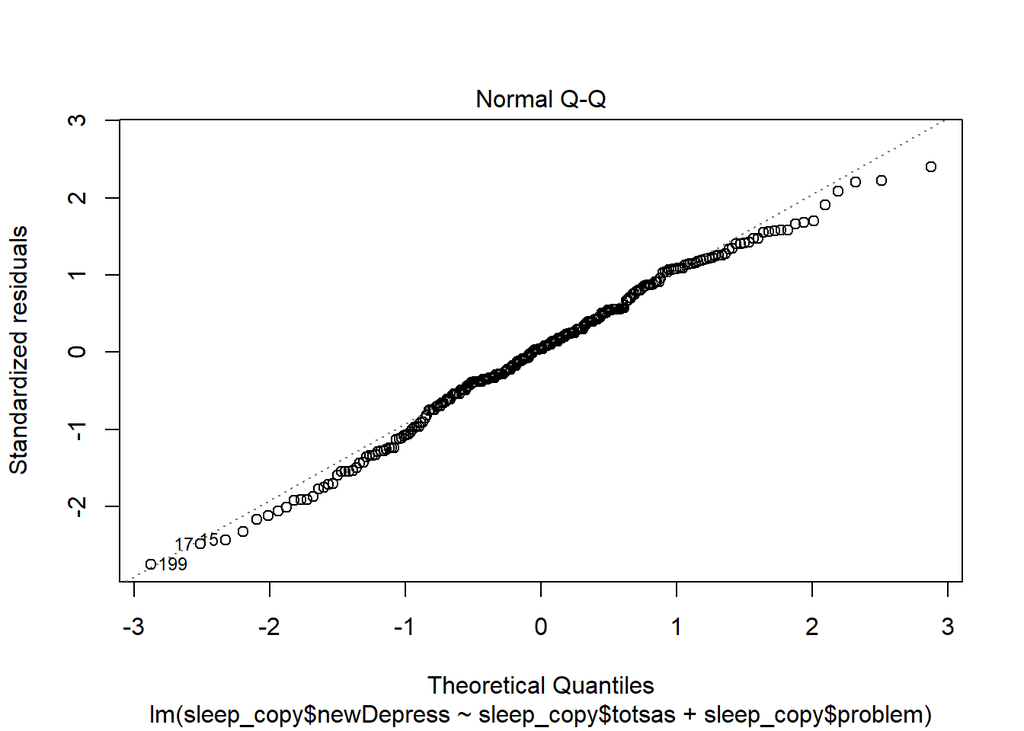

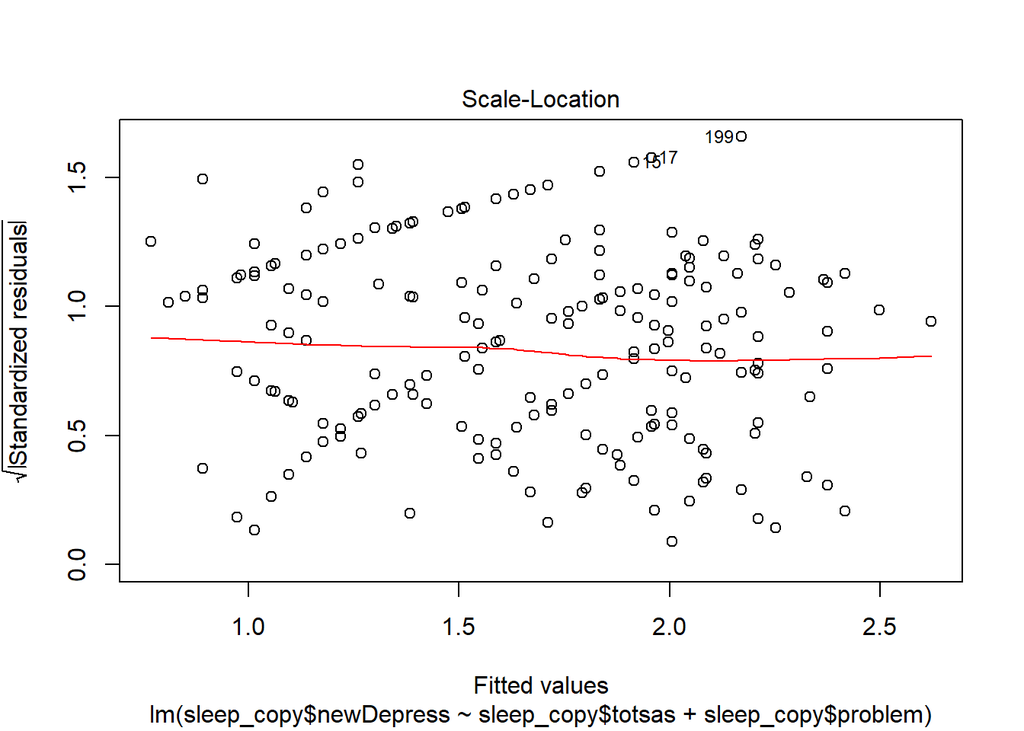

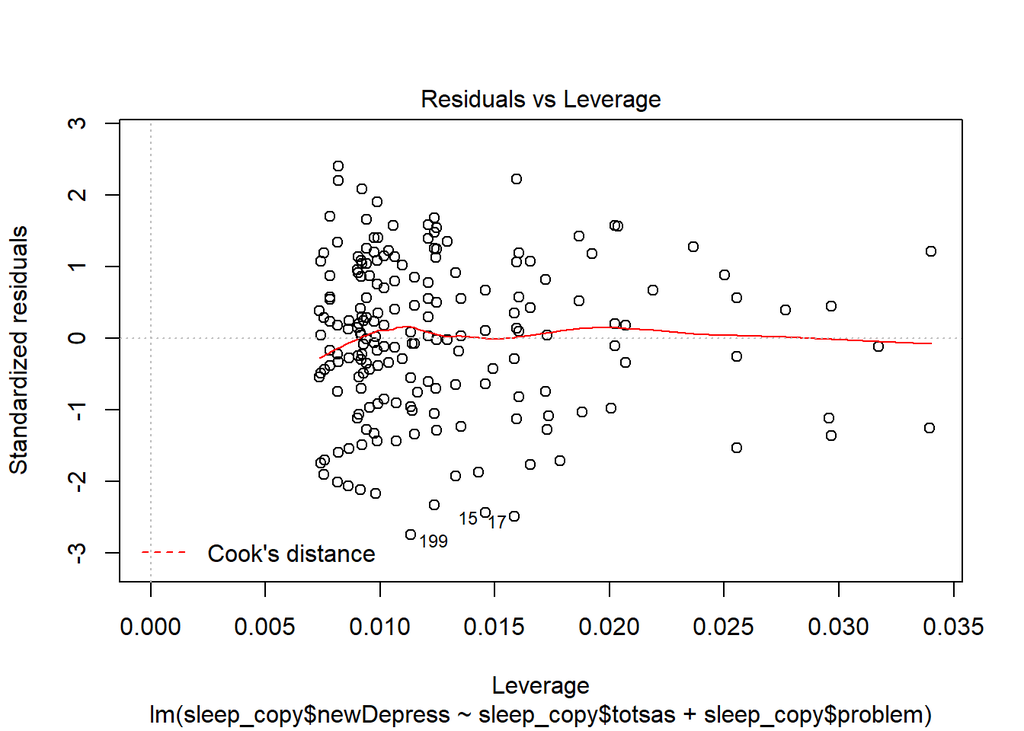

```r
#plot cook distance, qq plot, histogram
plot(model1)
```

```r
#colinearity
car::vif(model1)
```

```
##  sleep_copy$totsas sleep_copy$problem
##           1.385354           1.385354
```

```r
#tolerence
1/car::vif(model1)
```

```
##  sleep_copy$totsas sleep_copy$problem
##          0.7218373          0.7218373
```